# ZIP Code CARR Description

Author

Kate Nelson & Tuan Nguyen

Published

September 27, 2024

## CARR

The CARR (Community assets and relative rurality) index is a continuous, multidimensional measure of rurality based on the concept of sustainable development that integrates measures of environmental, social, and economic resources. The index incorporates traditional rurality measures such as population density, distance from metropolitan areas, and developed area with measures of availability and accessibility of 70 different infrastructure types that support essential community services and community amenities. The index uses data last updated in 2019 and was originally constructed for census block-groups in the coterminous United States. The original dataset (K. Nelson and Nguyen 2022) can be found at Zenodo and was described in an article in the Journal of Rural Studies (K. S. Nelson and Nguyen 2023).

## ZIP Code CARR

To operationalize CARR for ZIP code boundaries we computed area-weighted averages of the original block-group scale CARR. U.S. [Census Bureau ZIP code tabulation areas (ZCTAs)](https://www.census.gov/programs-surveys/geography/guidance/geo-areas/zctas.html) were used to approximate ZIP code boundaries. A ZCTA to ZIP code crosswalk dataset[^1] was used to associate ZCTAs to postal ZIP codes. *Note that the UDS Mapper website, including the crosswalk dataset, are not functioning as of September, 2024. However, additional crosswalks can be found at [GitHub](https://github.com/censusreporter/acs-aggregate/blob/master/crosswalks/zip_to_zcta/ZIP_ZCTA_README.md) and via the [US Department of Housing and Urban Development](https://www.huduser.gov/portal/datasets/usps_crosswalk.html)*.

In addition to presenting the area weighted average CARR scores, we also independently calculated area weighted averages for each constituent component of CARR. U.S. census urban-rural categorizations and USDA ERS rural urban continuum code (RUCC) classifications were summarized by taking the mode across all block groups intersecting with a ZIP code.

The values of the ZIP code CARR scores fall within the original range of CARR scores (0-1), where a value of 0 means very urban with high concentrations of services and amenities and a value of 1 means very rural with low concentrations of services and amenities.

However, the distribution of CARR by ZIP codes is shifted towards higher scores and the range is compressed (as should be expected from the aggregation process). The minimum score is **0.31**, the maximum score is **0.99**, and the mean score is **0.53**. (In the original CARR the mean value was ~0.5.)

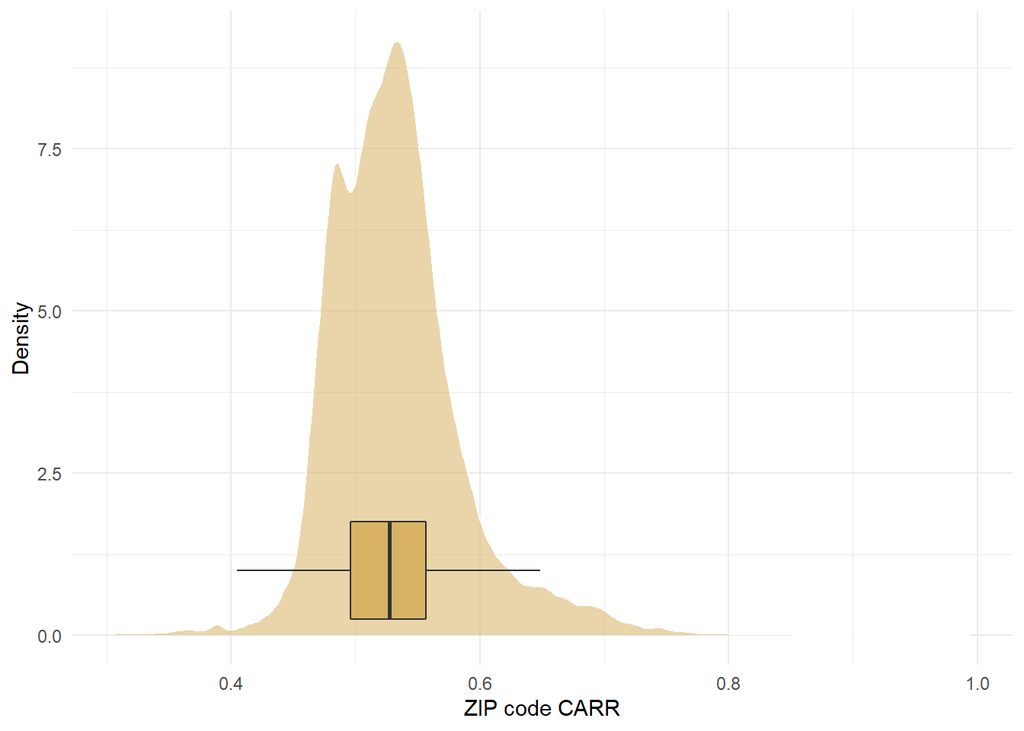

The spatial distribution of CARR across ZIP codes is consistent with the original CARR. *Note that there are no official ZIP code boundaries for some areas, particularly in the inter-mountain west region, including parts of: California, Nevada, Utah, Wyoming, Idaho, Oregon, Washington, Arizona and New Mexico.*

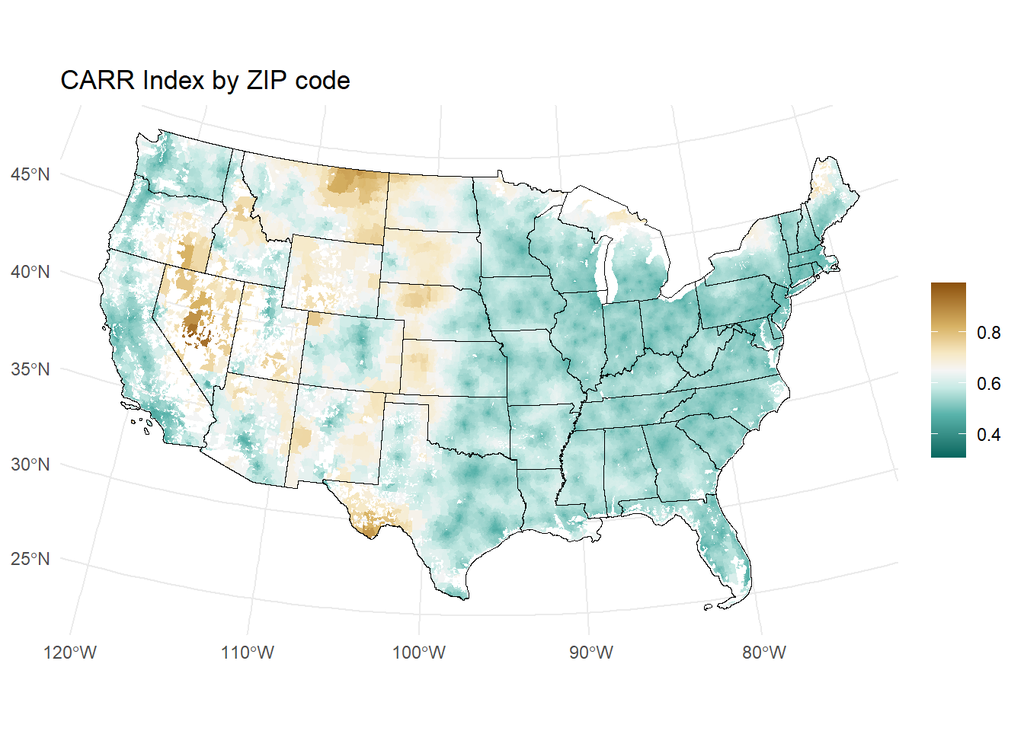

Like the original CARR, the index values at the ZIP code level indicate generally higher values of CARR in census designated rural areas but with a large degree of overlap in urban and rural CARR scores.

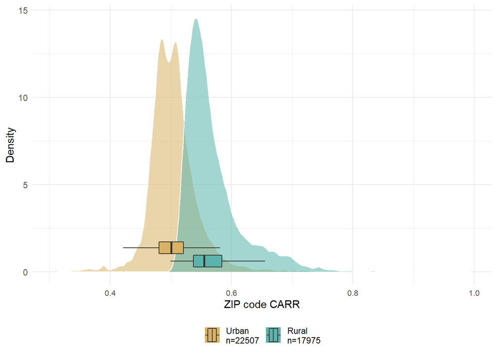

In addition, the ZIP code CARR scores generally tend to increase with increasing rurality in terms of RUCC but with large amounts of overlap.

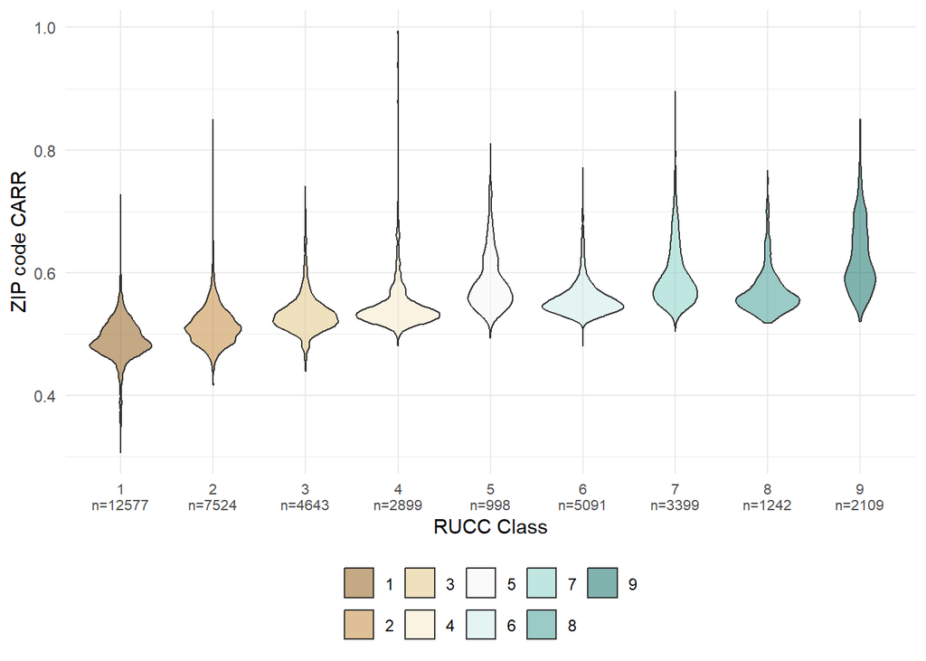

The availability component spatial distribution is consistent with the original CARR. Larger values of this component, which has an inverse relationship to the final CARR score, are associated with greater density of services and amenities and are generally found in more developed metropolitan areas. *Note that this component has a highly skewed distribution and is log transformed for visualization purposes.*

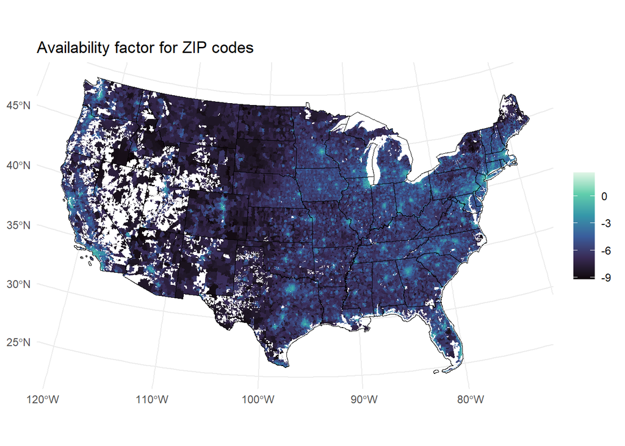

The three accessibility components’ spatial distributions are consistent with the original CARR as well. Larger values of the first accessibility factor are associated with greater distances to amenities. Larger values of the second accessibility factor are associated with increased distance to essential services. Larger values of the third accessibility factor are associated with greater distances to both amenities and natural resource extraction (e.g. peri-urban).

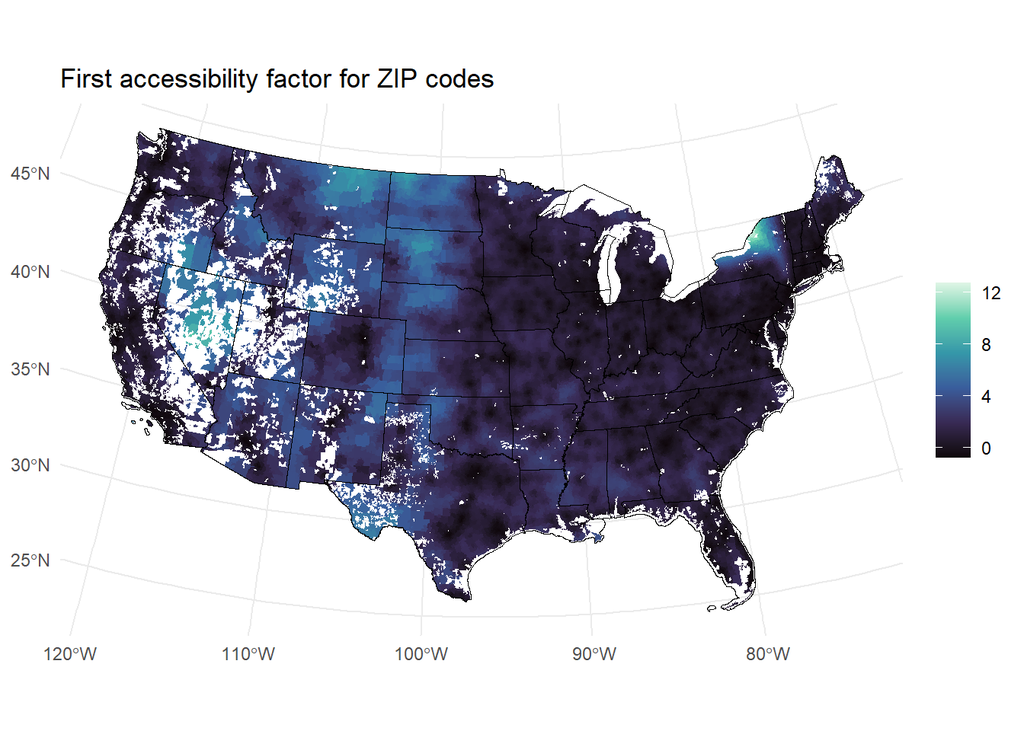

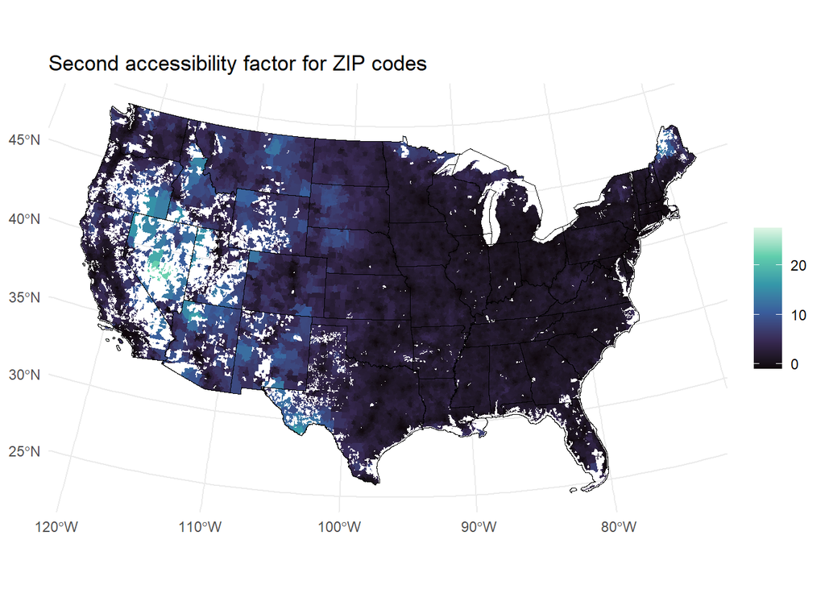

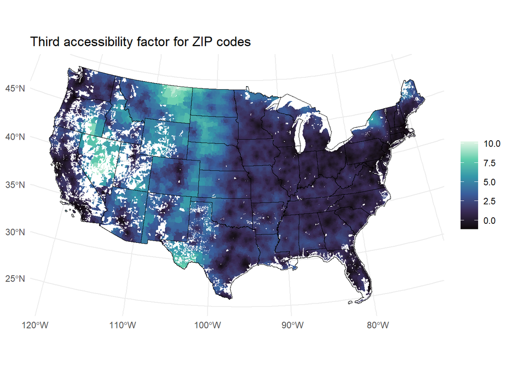

We also see that the relationships between ZIP code CARR and population density, distance to metro areas, and developed land cover meet expectations. CARR has a negative relationship with population density and developed land cover and a positive relationship with distance to metro areas.

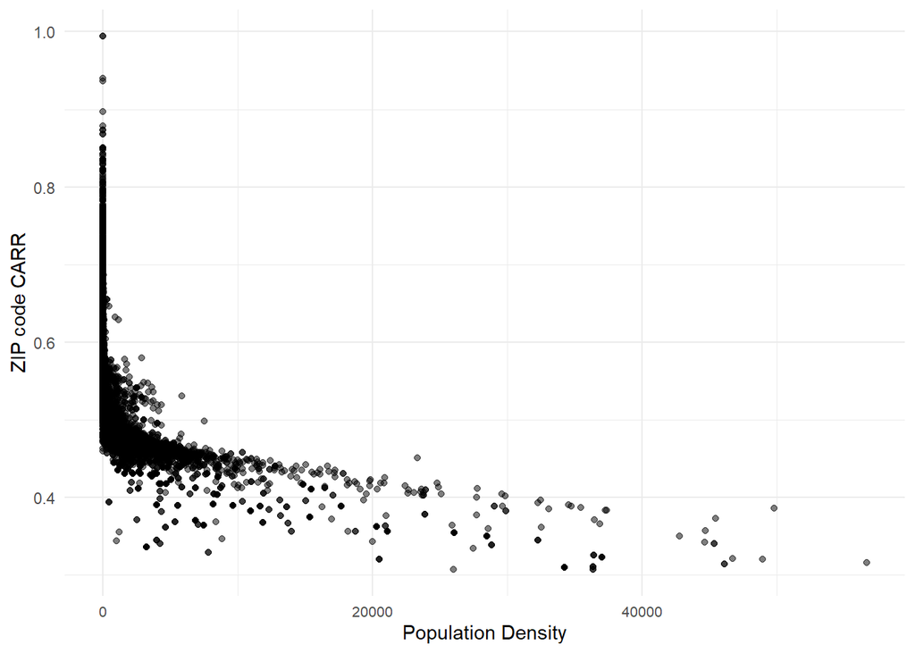

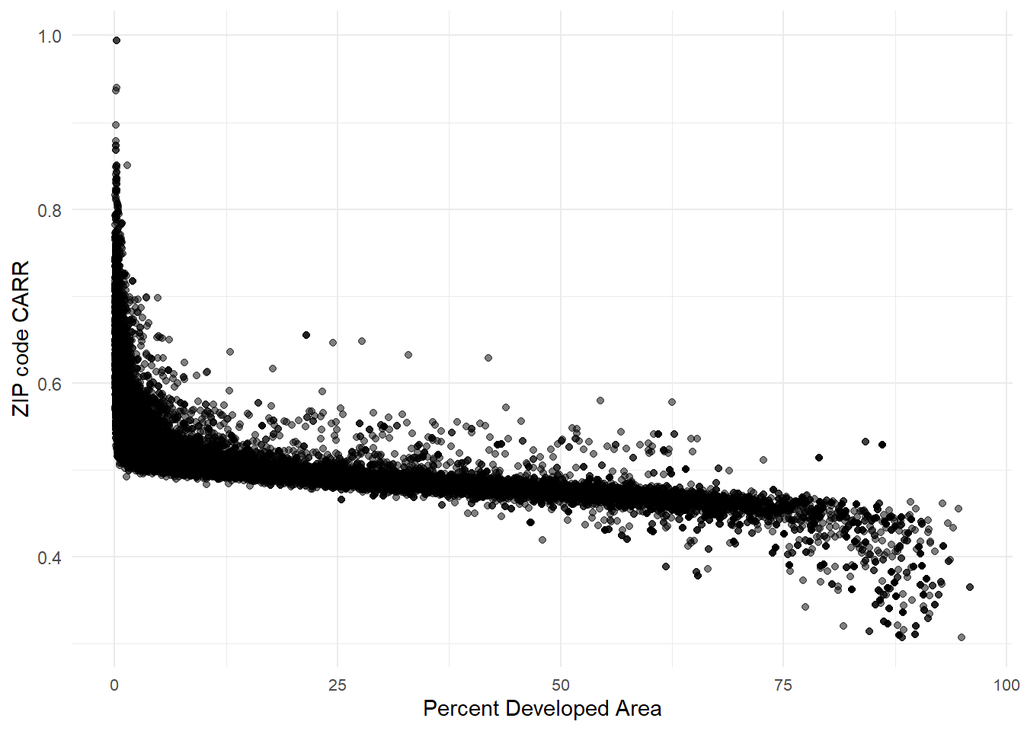

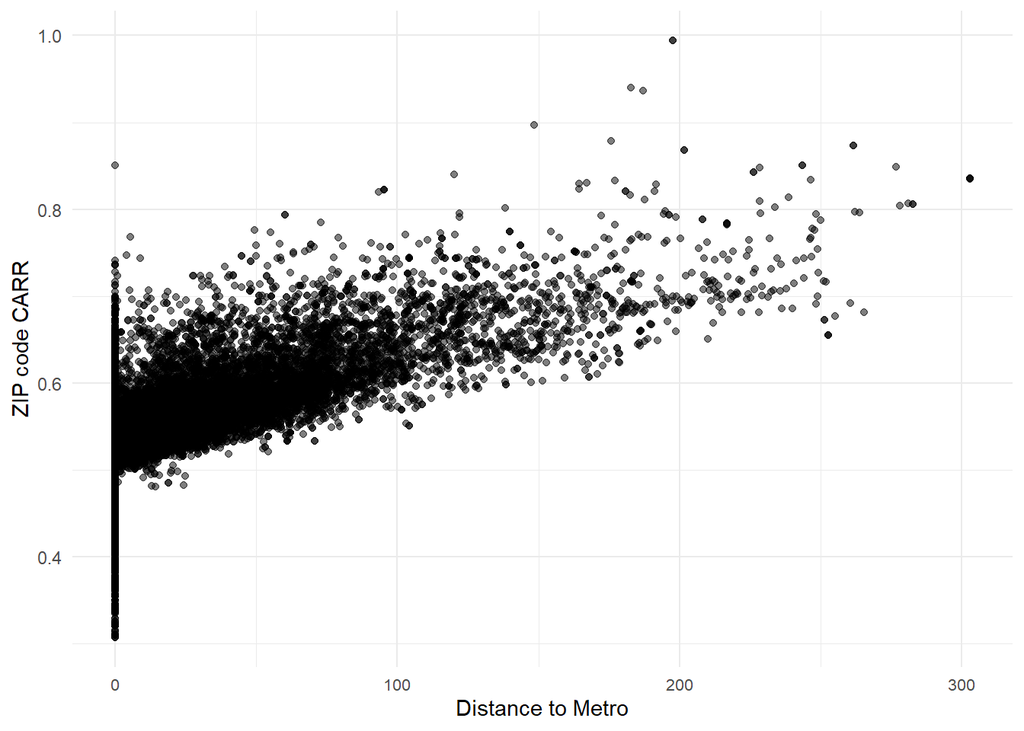

## References

Nelson, Katherine S., and Tuan D. Nguyen. 2023. “Community Assets and Relative Rurality Index: A Multi-Dimensional Measure of Rurality.” *Journal of Rural Studies* 97 (January): 322–33. https://doi.org/10.1016/j.jrurstud.2022.12.025.

Nelson, Katherine, and Tuan Nguyen. 2022. “Community Assets and Relative Rurality Index.” Zenodo. https://doi.org/10.5281/ZENODO.8072187.

## Footnotes

[^1]: John Snow, Inc. “ZIP Code to ZCTA Crosswalk.” UDS Mapper, 2019. https://udsmapper.org/wp-content/uploads/2020/09/Zip_to_zcta_crosswalk_2020.xlsx.